# Ingestion Processing Report

Pier Lorenzo Paracchini

22 mai 2016

# Corpora (from a Sample)

```r
rm(list = ls())
source("./scripts/visualization.R")
load("./data/02_cleaningSamples/corpora_randomSample_1.rdata_sentences.rdata_cleaned.rdata_tmCorpus.rdata_tdm_ng.rdata")
load("./data/03_termFrequency/randomSample_1_term_frequency.rdata")
```

## Twitter

### 1-grams

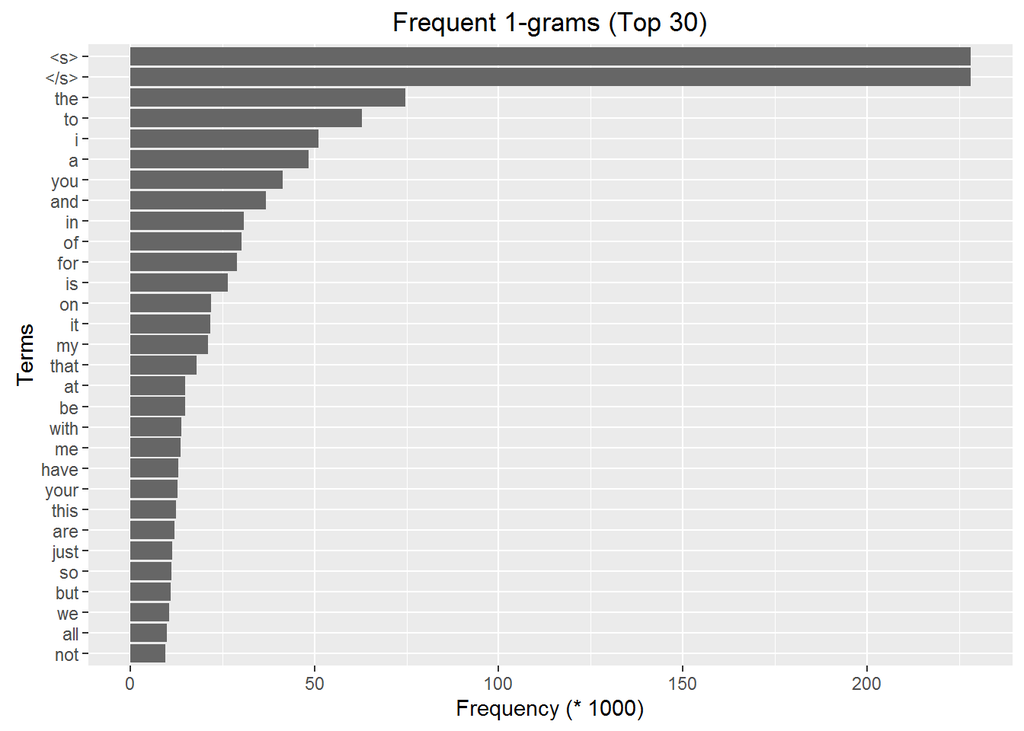

```r
corpus.tdm <- tdm_1g_corpus[["twitterCorpus"]]
corpus.allTerms <- term_frequency_1g[["twitterCorpus"]]

frequentTermsLimited.df <- getTermFrequencyInformationOrderedByTermFrequency(corpus.tdm, 1500)
visualizeBarPlot(ftm.df = frequentTermsLimited.df, titleBarPlot = "Frequent 1-grams")
```

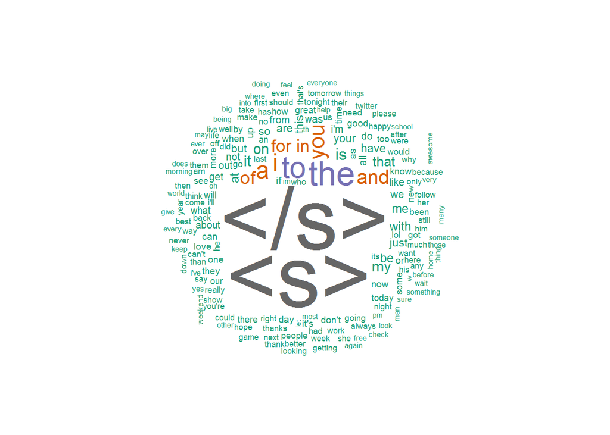

```r
visualizeWordcloud(ftm.df = frequentTermsLimited.df)
```

```r
a <- getSomeInfoABoutCorpora(allFtm.df = corpus.allTerms)
```

**How many unique words do you need in a frequency sorted dictionary to cover 50% of all word instances in the language? 90%?**

| N = number of tokens | V = vocabulary size | 50% coverage | 90% coverage |
| --- | --- | --- | --- |
| 2704169 | 78498 | 61 | 4125 |

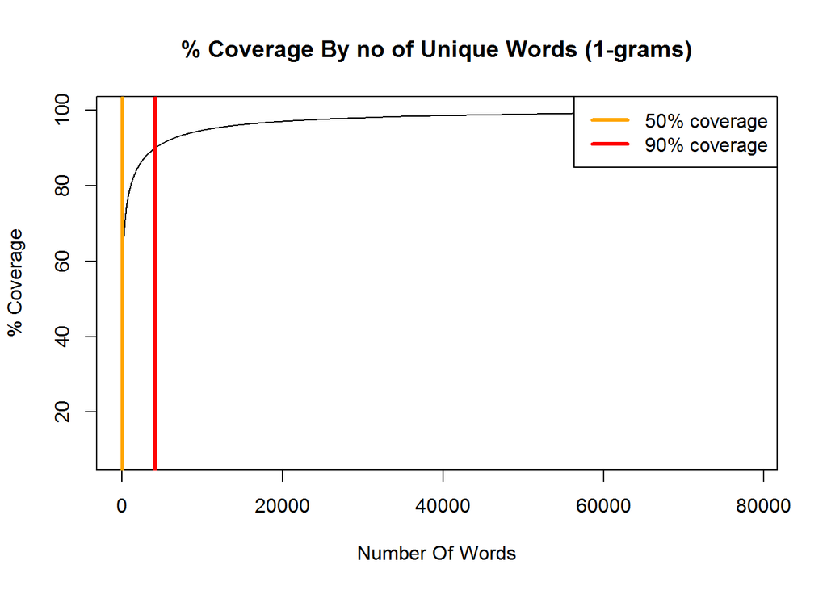

```r
visualizeCumuluativeCoverage(allFtm.df = corpus.allTerms, title = "% Coverage By no of Unique Words (1-grams)")
```

### 2-grams

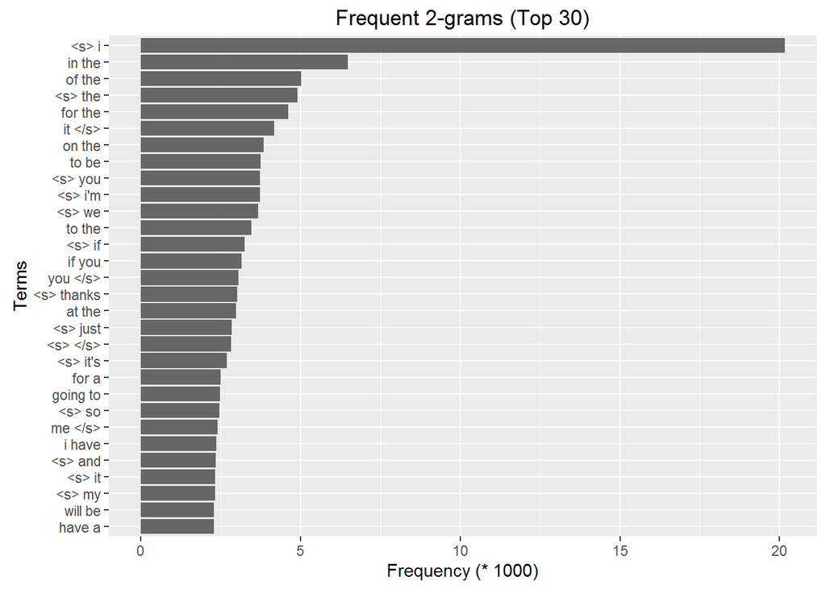

```r
corpus.tdm <- tdm_2g_corpus[["twitterCorpus"]]
corpus.allTerms <- term_frequency_2g[["twitterCorpus"]]

frequentTermsLimited.df <- getTermFrequencyInformationOrderedByTermFrequency(corpus.tdm, 1500)
visualizeBarPlot(ftm.df = frequentTermsLimited.df, titleBarPlot = "Frequent 2-grams")
```

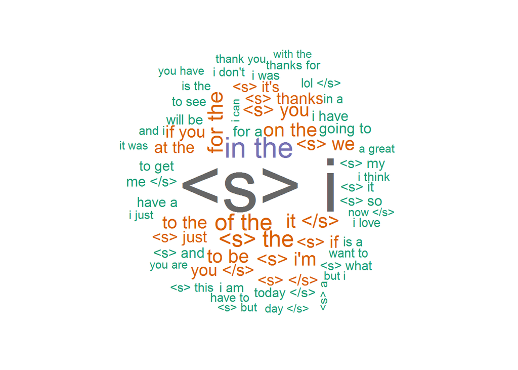

```r
visualizeWordcloud(ftm.df = frequentTermsLimited.df)
```

```r
a <- getSomeInfoABoutCorpora(allFtm.df = corpus.allTerms)
```

**How many unique words do you need in a frequency sorted dictionary to cover 50% of all word instances in the language? 90%?**

| N = number of tokens | V = vocabulary size | 50% coverage | 90% coverage |
| --- | --- | --- | --- |
| 2476053 | 762320 | 15208 | 514715 |

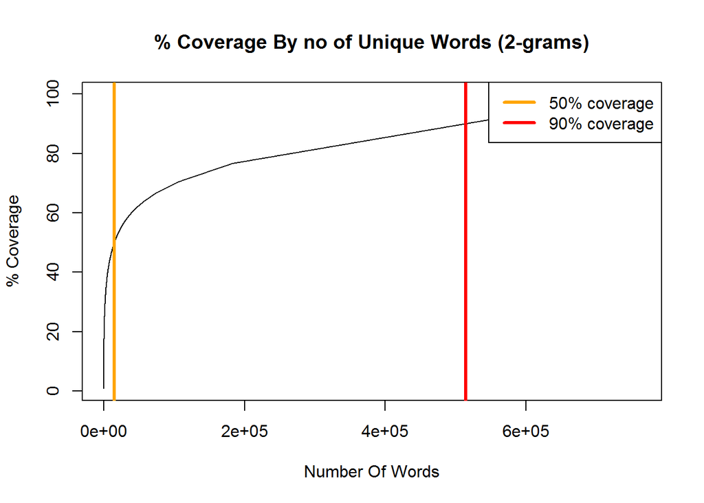

### 3-grams

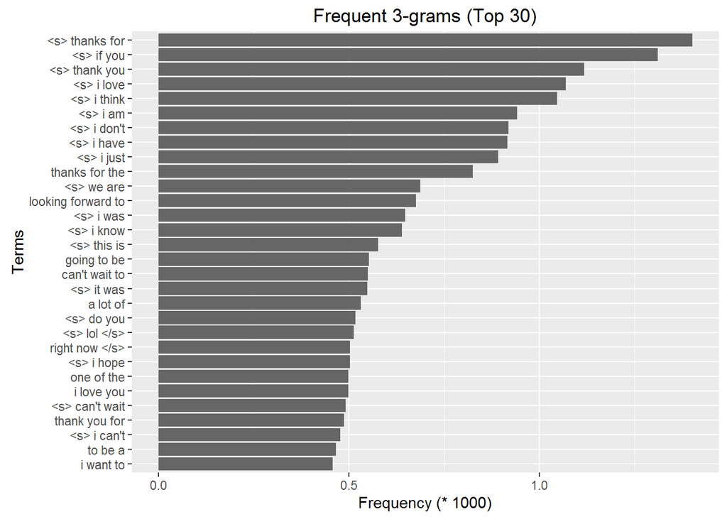

```r
corpus.tdm <- tdm_3g_corpus[["twitterCorpus"]]
corpus.allTerms <- term_frequency_3g[["twitterCorpus"]]

frequentTermsLimited.df <- getTermFrequencyInformationOrderedByTermFrequency(corpus.tdm, 300)
visualizeBarPlot(ftm.df = frequentTermsLimited.df, titleBarPlot = "Frequent 3-grams")
```

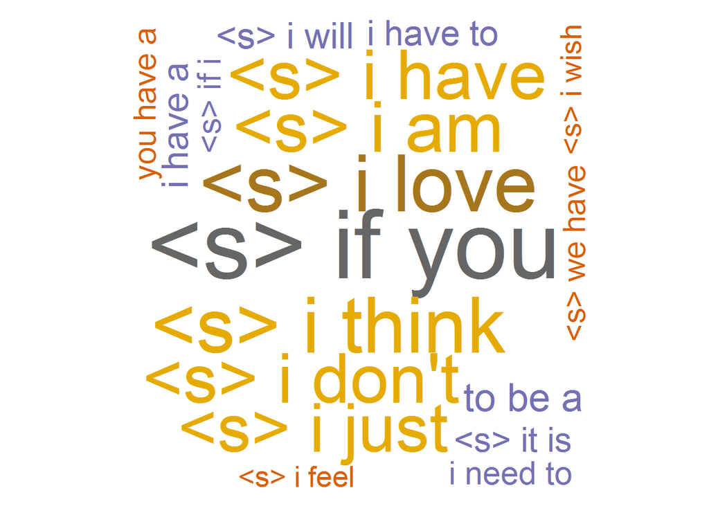

```r
visualizeWordcloud(ftm.df = frequentTermsLimited.df)
```

```r
a <- getSomeInfoABoutCorpora(allFtm.df = corpus.allTerms)
```

**How many unique words do you need in a frequency sorted dictionary to cover 50% of all word instances in the language? 90%?**

| N = number of tokens | V = vocabulary size | 50% coverage | 90% coverage |
| --- | --- | --- | --- |
| 2247936 | 1554005 | 430037 | 1329212 |

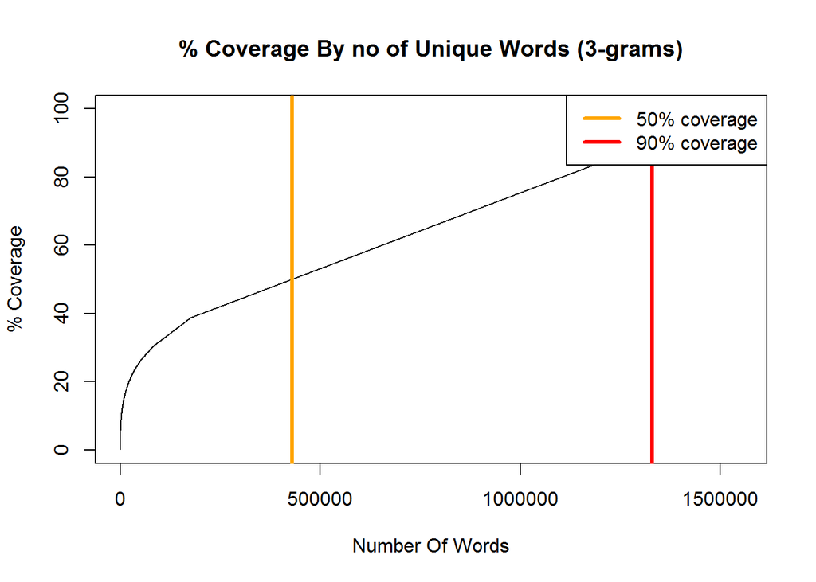

```r
visualizeCumuluativeCoverage(allFtm.df = corpus.allTerms, title = "% Coverage By no of Unique Words (3-grams)")
```

## News

### 1-grams

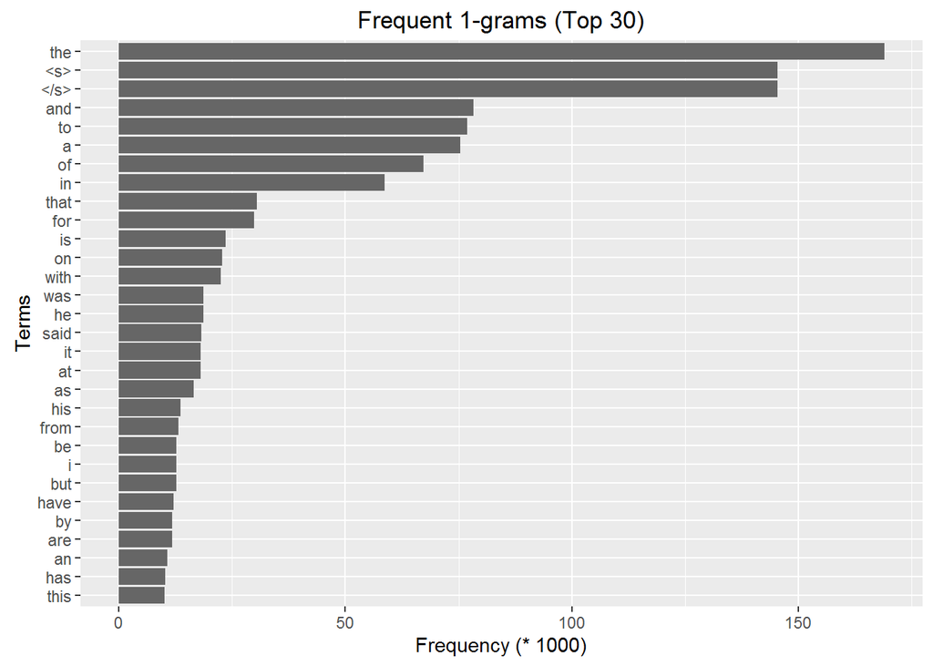

```r
corpus.tdm <- tdm_1g_corpus[["newsCorpus"]]
corpus.allTerms <- term_frequency_1g[["newsCorpus"]]

frequentTermsLimited.df <- getTermFrequencyInformationOrderedByTermFrequency(corpus.tdm, 1500)
visualizeBarPlot(ftm.df = frequentTermsLimited.df, titleBarPlot = "Frequent 1-grams")
```

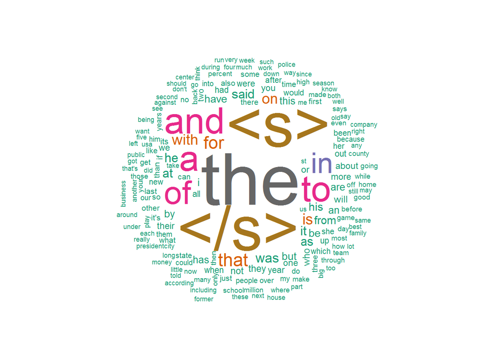

```r
visualizeWordcloud(ftm.df = frequentTermsLimited.df)
```

```r
a <- getSomeInfoABoutCorpora(allFtm.df = corpus.allTerms)
```

**How many unique words do you need in a frequency sorted dictionary to cover 50% of all word instances in the language? 90%?**

| N = number of tokens | V = vocabulary size | 50% coverage | 90% coverage |
| --- | --- | --- | --- |
| 3157273 | 81101 | 115 | 6806 |

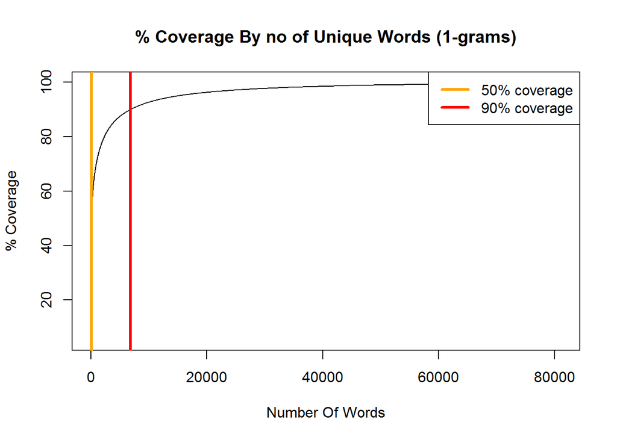

```r
visualizeCumuluativeCoverage(allFtm.df = corpus.allTerms, title = "% Coverage By no of Unique Words (1-grams)")
```

### 2-grams

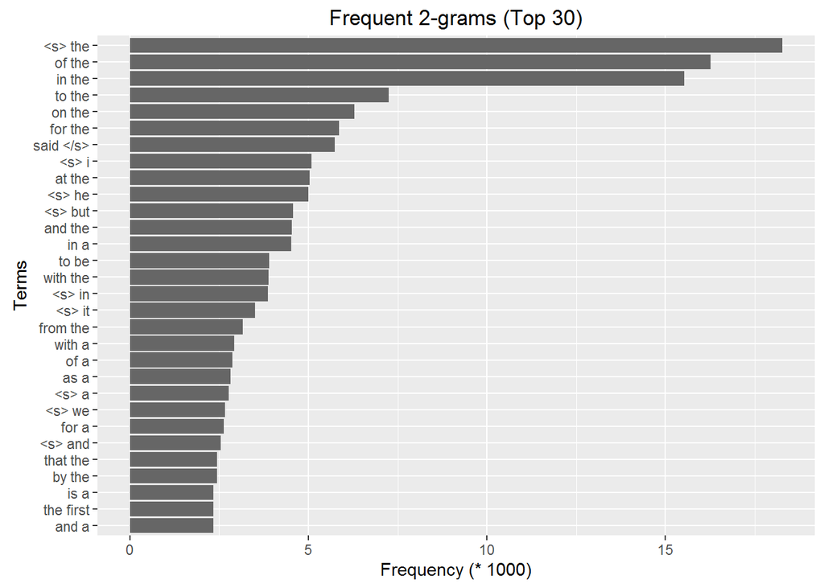

```r
corpus.tdm <- tdm_2g_corpus[["newsCorpus"]]
corpus.allTerms <- term_frequency_2g[["newsCorpus"]]

frequentTermsLimited.df <- getTermFrequencyInformationOrderedByTermFrequency(corpus.tdm, 1500)
visualizeBarPlot(ftm.df = frequentTermsLimited.df, titleBarPlot = "Frequent 2-grams")
```

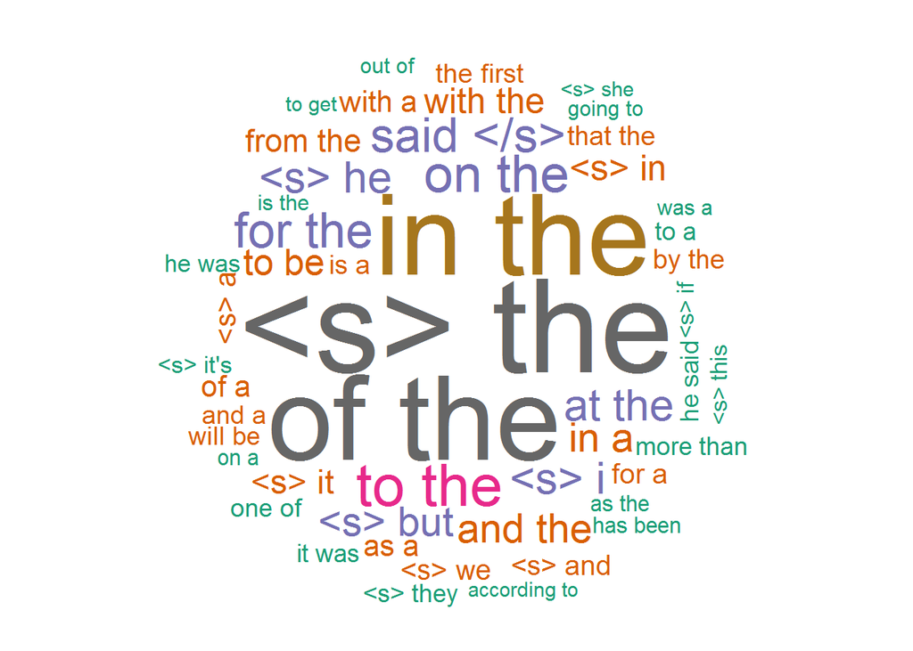

```r
visualizeWordcloud(ftm.df = frequentTermsLimited.df)
```

```r
a <- getSomeInfoABoutCorpora(allFtm.df = corpus.allTerms)
```

**How many unique words do you need in a frequency sorted dictionary to cover 50% of all word instances in the language? 90%?**

| N = number of tokens | V = vocabulary size | 50% coverage | 90% coverage |
| --- | --- | --- | --- |
| 3011843 | 1017258 | 34222 | 716074 |

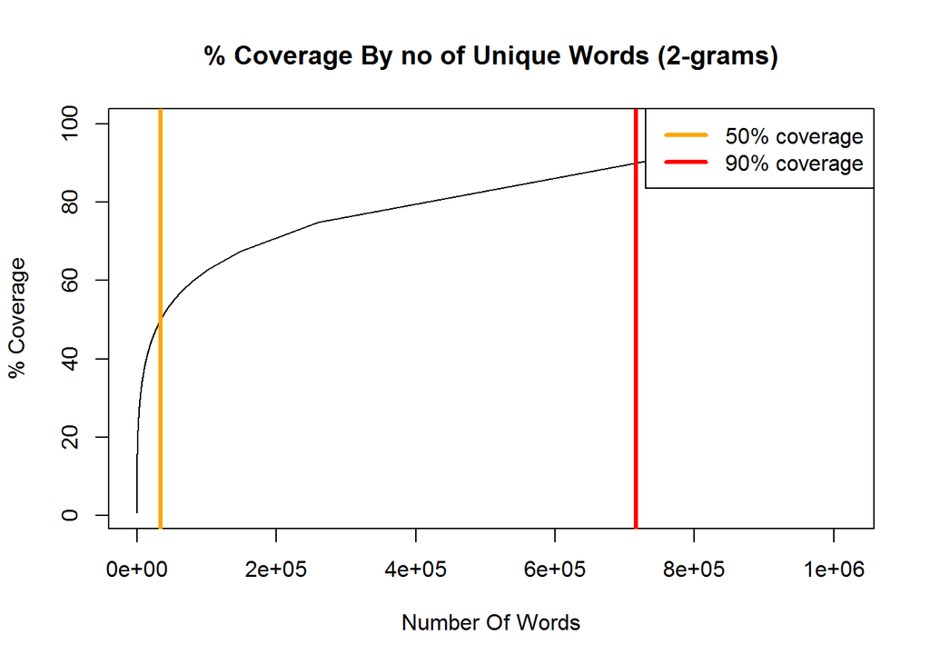

### 3-grams

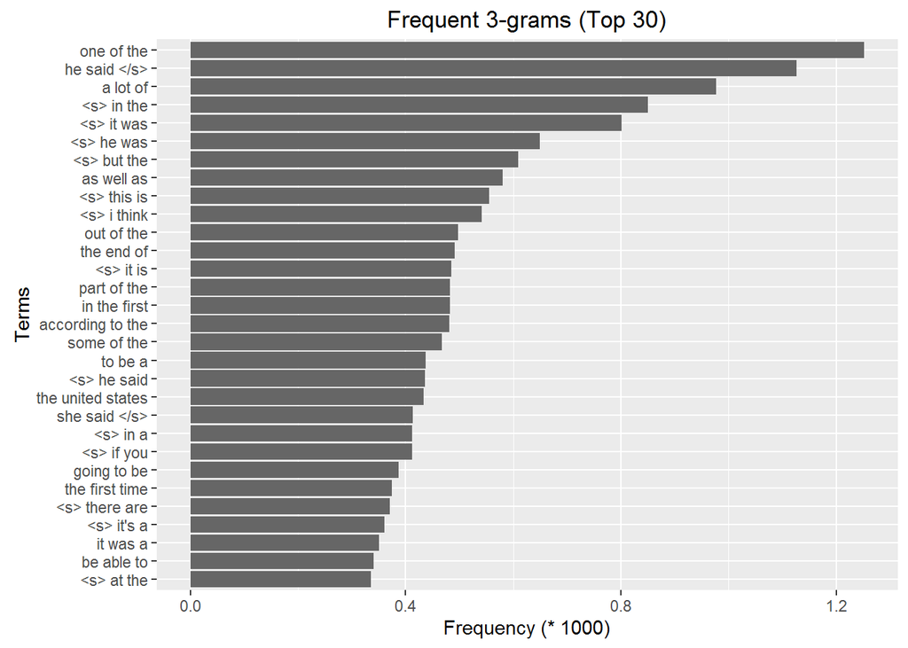

```r
corpus.tdm <- tdm_3g_corpus[["newsCorpus"]]
corpus.allTerms <- term_frequency_3g[["newsCorpus"]]

frequentTermsLimited.df <- getTermFrequencyInformationOrderedByTermFrequency(corpus.tdm, 200)
visualizeBarPlot(ftm.df = frequentTermsLimited.df, titleBarPlot = "Frequent 3-grams")
```

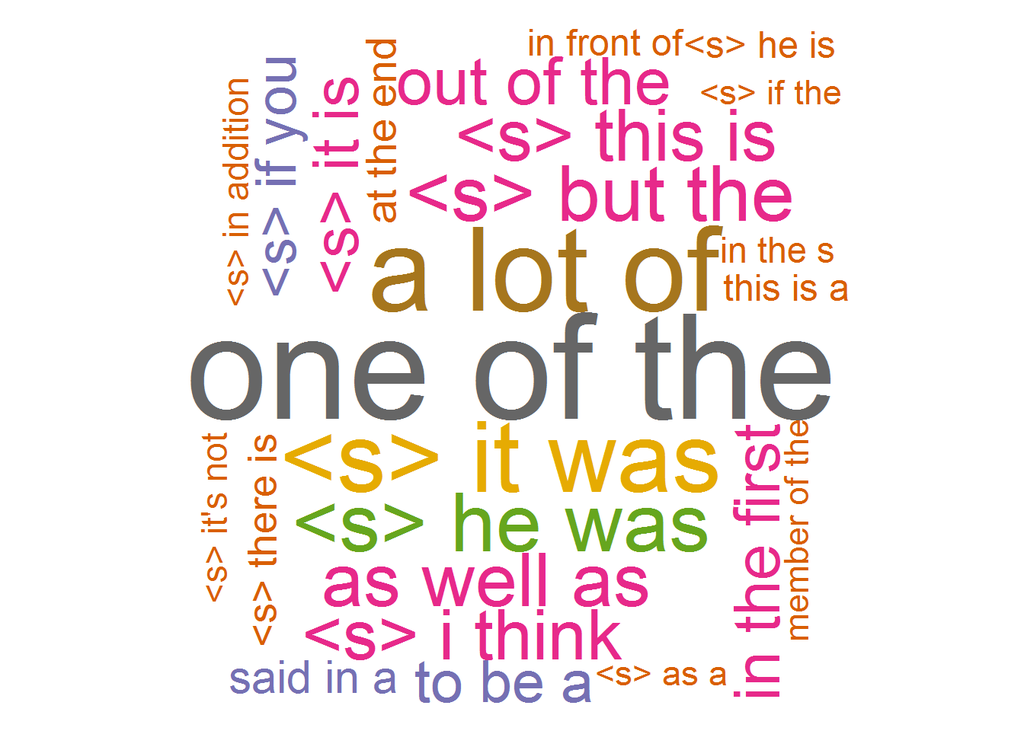

```r
visualizeWordcloud(ftm.df = frequentTermsLimited.df)
```

```r
a <- getSomeInfoABoutCorpora(allFtm.df = corpus.allTerms)
```

**How many unique words do you need in a frequency sorted dictionary to cover 50% of all word instances in the language? 90%?**

| N = number of tokens | V = vocabulary size | 50% coverage | 90% coverage |
| --- | --- | --- | --- |
| 2866413 | 2132289 | 699083 | 1845648 |

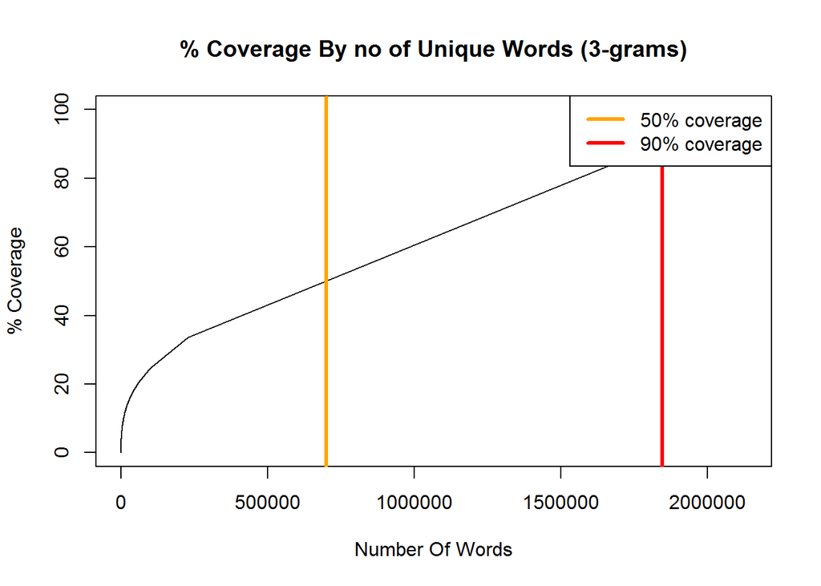

```r
visualizeCumuluativeCoverage(allFtm.df = corpus.allTerms, title = "% Coverage By no of Unique Words (3-grams)")
```

## Blogs

### 1-grams

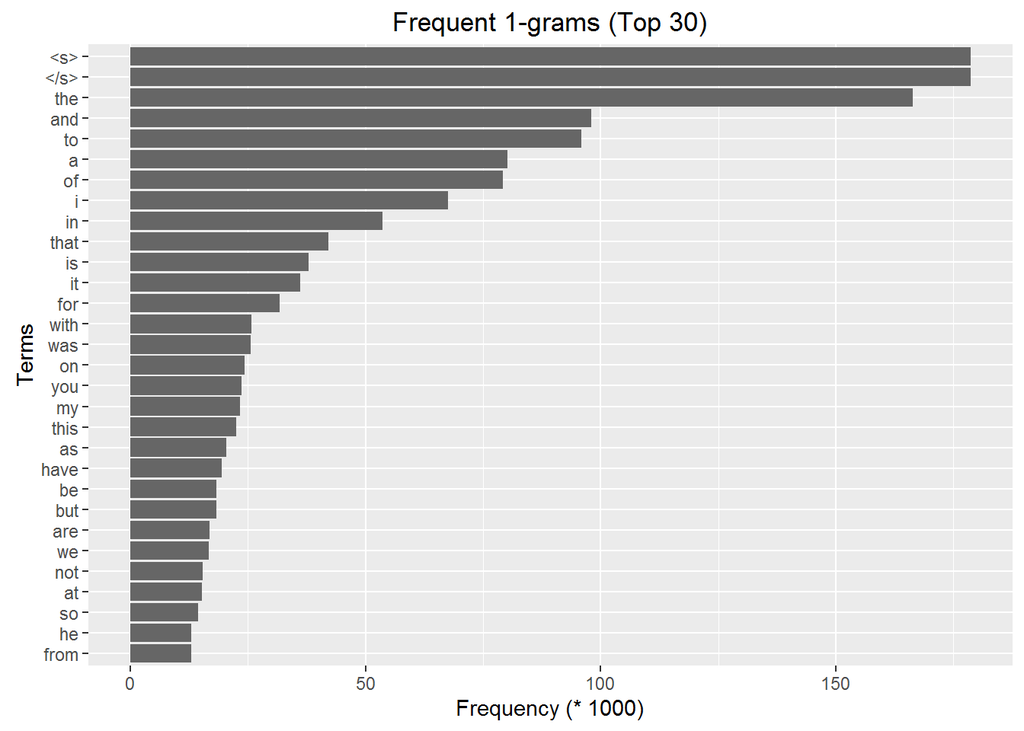

```r
corpus.tdm <- tdm_1g_corpus[["blogsCorpus"]]
corpus.allTerms <- term_frequency_1g[["blogsCorpus"]]

frequentTermsLimited.df <- getTermFrequencyInformationOrderedByTermFrequency(corpus.tdm, 1500)
visualizeBarPlot(ftm.df = frequentTermsLimited.df, titleBarPlot = "Frequent 1-grams")
```

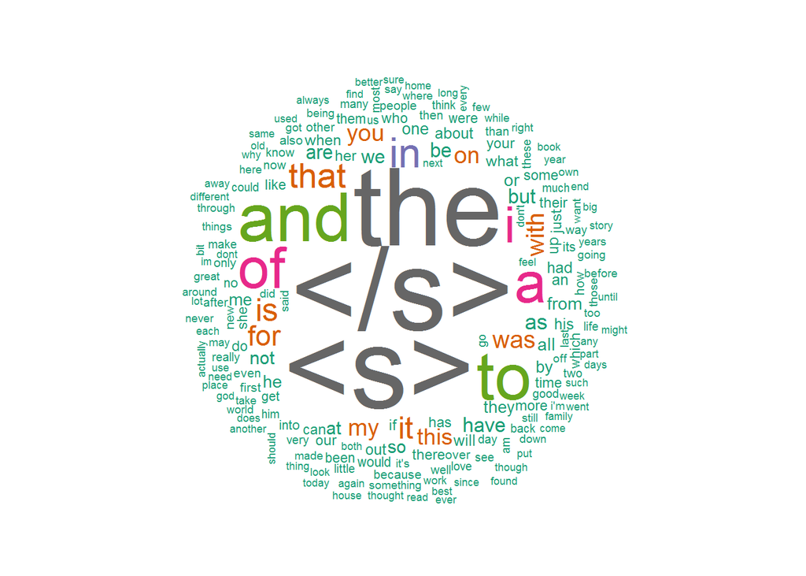

```r
visualizeWordcloud(ftm.df = frequentTermsLimited.df)
```

```r
a <- getSomeInfoABoutCorpora(allFtm.df = corpus.allTerms)
```

**How many unique words do you need in a frequency sorted dictionary to cover 50% of all word instances in the language? 90%?**

| N = number of tokens | V = vocabulary size | 50% coverage | 90% coverage |
| --- | --- | --- | --- |
| 3618054 | 83849 | 67 | 5250 |

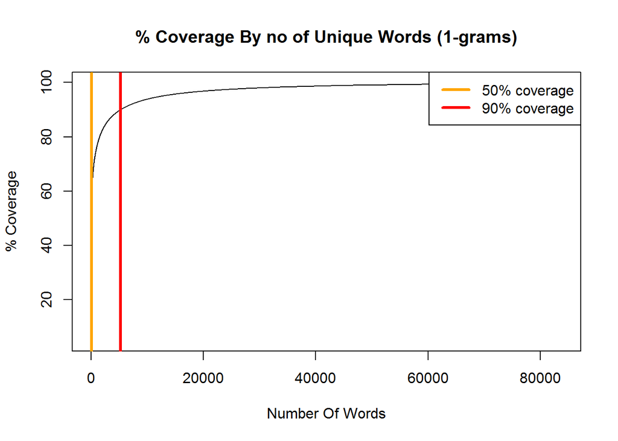

```r
visualizeCumuluativeCoverage(allFtm.df = corpus.allTerms, title = "% Coverage By no of Unique Words (1-grams)")
```

### 2-grams

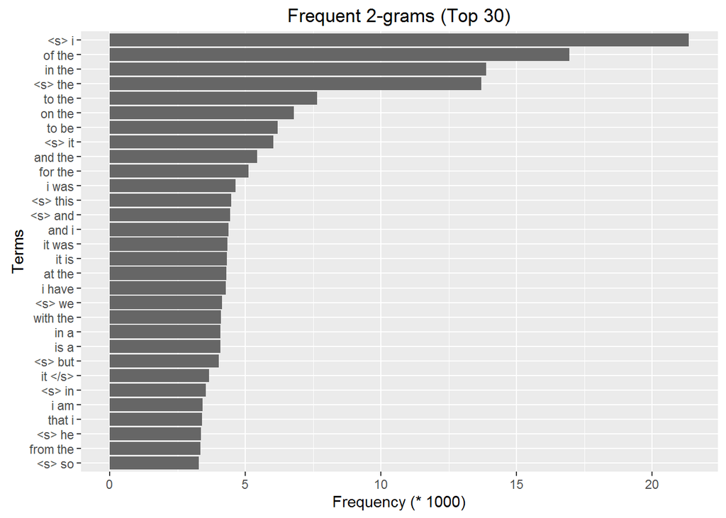

```r
corpus.tdm <- tdm_2g_corpus[["blogsCorpus"]]
corpus.allTerms <- term_frequency_2g[["blogsCorpus"]]

frequentTermsLimited.df <- getTermFrequencyInformationOrderedByTermFrequency(corpus.tdm, 1500)
visualizeBarPlot(ftm.df = frequentTermsLimited.df, titleBarPlot = "Frequent 2-grams")
```

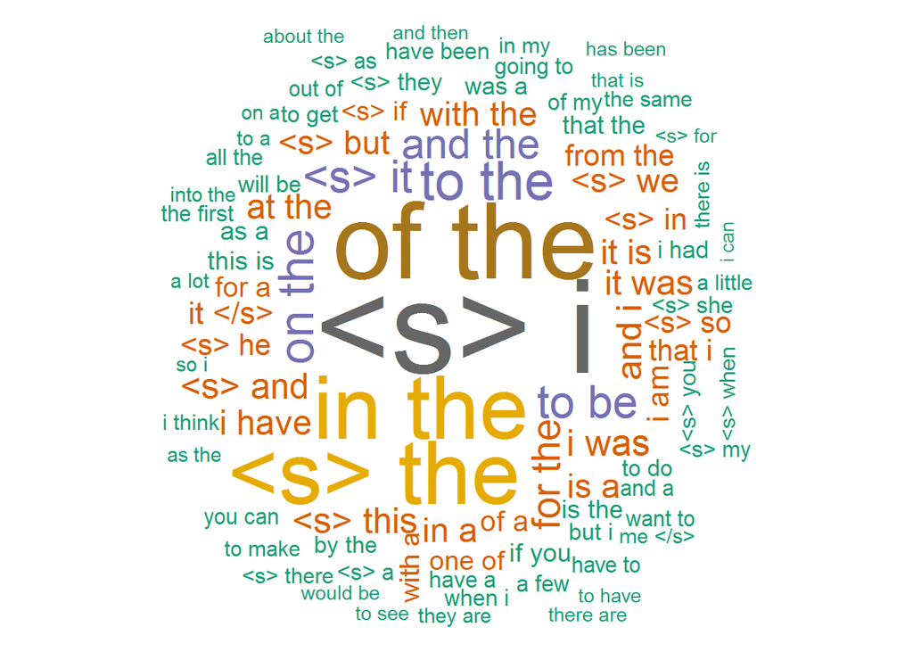

```r
visualizeWordcloud(ftm.df = frequentTermsLimited.df)
```

```r
a <- getSomeInfoABoutCorpora(allFtm.df = corpus.allTerms)
```

**How many unique words do you need in a frequency sorted dictionary to cover 50% of all word instances in the language? 90%?**

| N = number of tokens | V = vocabulary size | 50% coverage | 90% coverage |
| --- | --- | --- | --- |
| 3439404 | 1012269 | 20278 | 668329 |

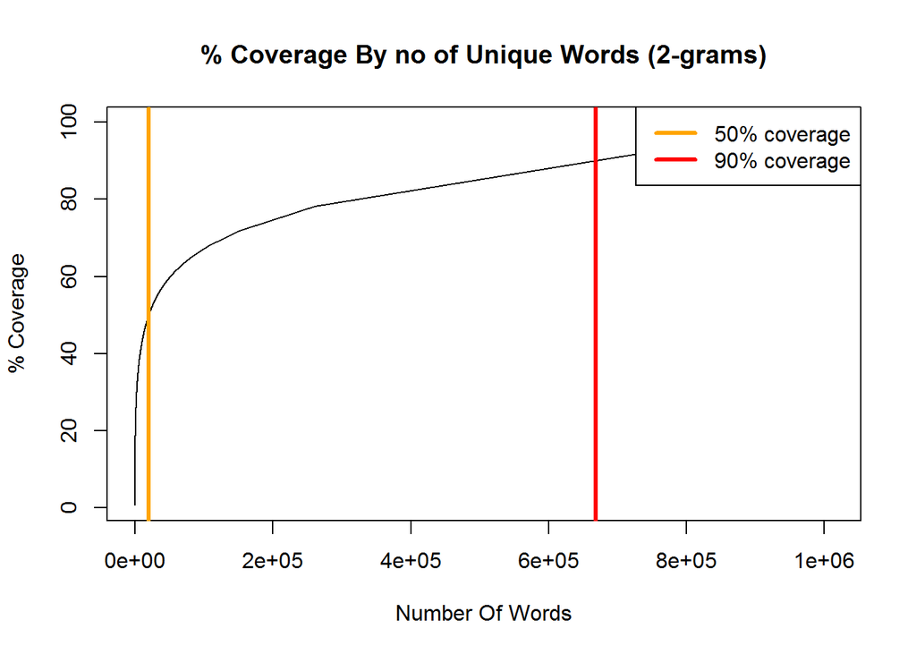

### 3-grams

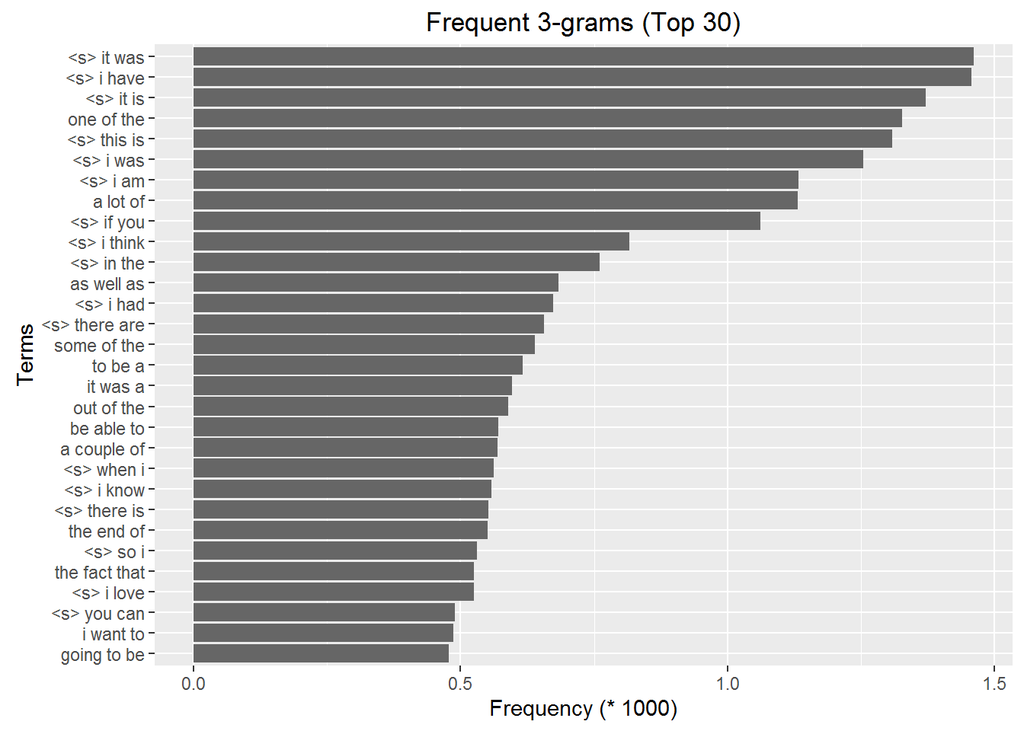

```r
corpus.tdm <- tdm_3g_corpus[["blogsCorpus"]]
corpus.allTerms <- term_frequency_3g[["blogsCorpus"]]

frequentTermsLimited.df <- getTermFrequencyInformationOrderedByTermFrequency(corpus.tdm, 200)
visualizeBarPlot(ftm.df = frequentTermsLimited.df, titleBarPlot = "Frequent 3-grams")
```

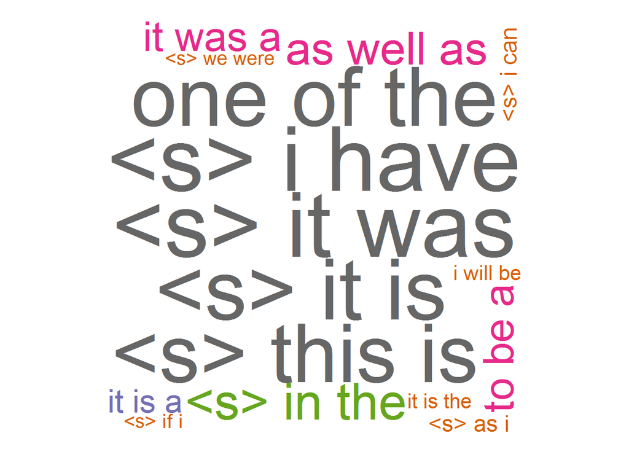

```r
visualizeWordcloud(ftm.df = frequentTermsLimited.df)
```

```r
a <- getSomeInfoABoutCorpora(allFtm.df = corpus.allTerms)
```

**How many unique words do you need in a frequency sorted dictionary to cover 50% of all word instances in the language? 90%?**

| N = number of tokens | V = vocabulary size | 50% coverage | 90% coverage |
| --- | --- | --- | --- |
| 3260754 | 2268375 | 637998 | 1942300 |

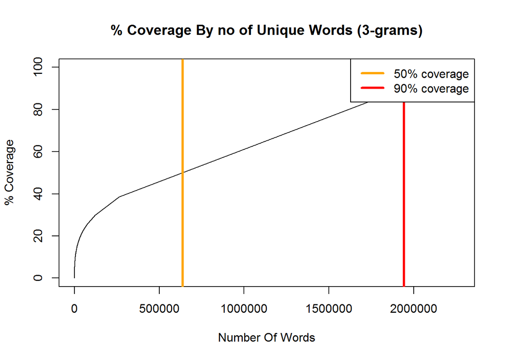

```r
visualizeCumuluativeCoverage(allFtm.df = corpus.allTerms, title = "% Coverage By no of Unique Words (3-grams)")
```

# Corpora (all samples)

```r
rm(list = ls())
source("./scripts/visualization.R")
load("./data/03_termFrequency/randomSample_all_collapsed_term_frequency.rdata")
```

## 1-grams

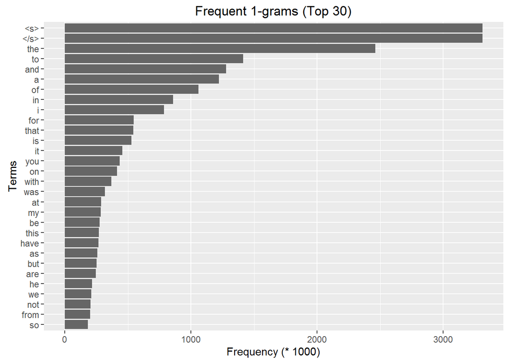

```r
corpus.allTerms <- s.1g

frequentTermsLimited.df <- getTermFrequencyInformationOrderedByTermFrequency.1(corpus.allTerms, 1500)
visualizeBarPlot(ftm.df = frequentTermsLimited.df, titleBarPlot = "Frequent 1-grams")
```

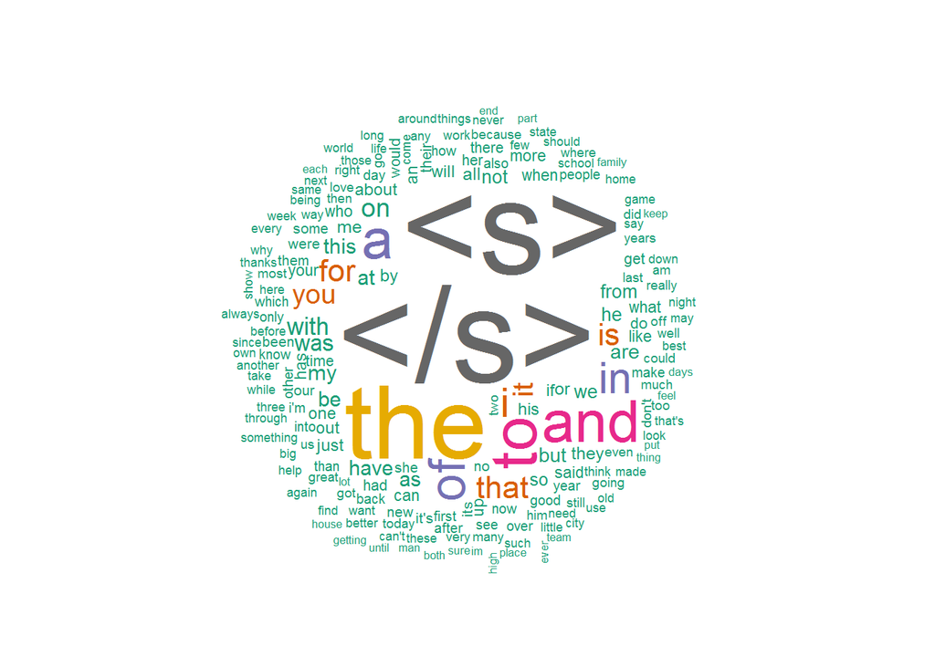

```r
visualizeWordcloud(ftm.df = frequentTermsLimited.df)
```

```r
frequentTermsLimited.df <- getTermFrequencyInformationOrderedByTermFrequency.1(corpus.allTerms, 1)
a <- getSomeInfoABoutCorpora.1(x = frequentTermsLimited.df)
```

**How many unique words do you need in a frequency sorted dictionary to cover 50% of all word instances in the language? 90%?**

| N = number of tokens | V = vocabulary size | 50% coverage | 90% coverage |
| --- | --- | --- | --- |
| 56859890 | 362734 | 81 | 6141 |

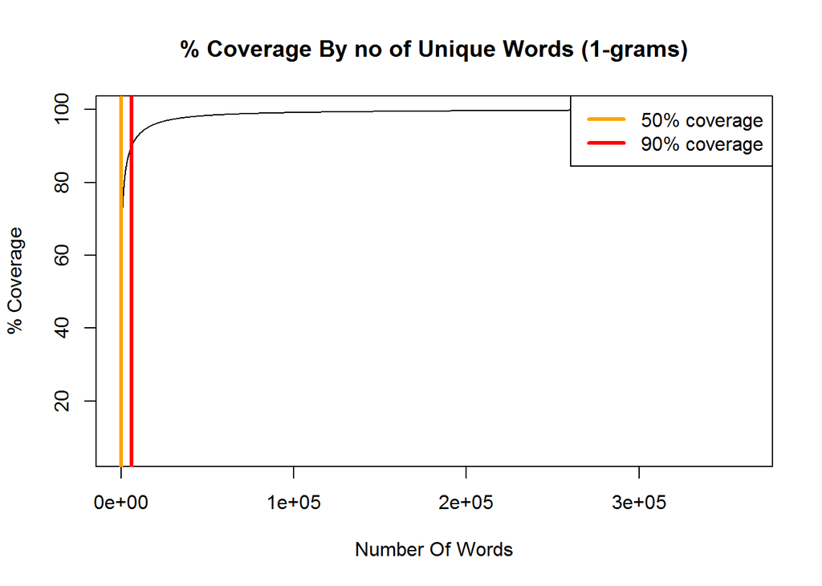

```r
visualizeCumuluativeCoverage.1(x = frequentTermsLimited.df, title = "% Coverage By no of Unique Words (1-grams)")
```